# Question

The continuous random variable $X$ follows the distribution shown by the density curve and spinner below. It has a mean of $\mu_{X}=26.69$ and standard deviation of $\sigma_{X}=1.25$.

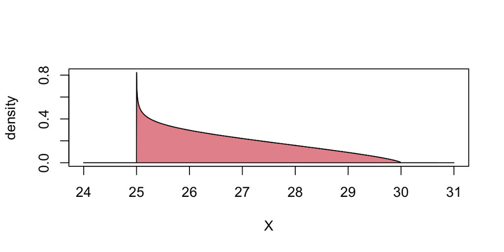

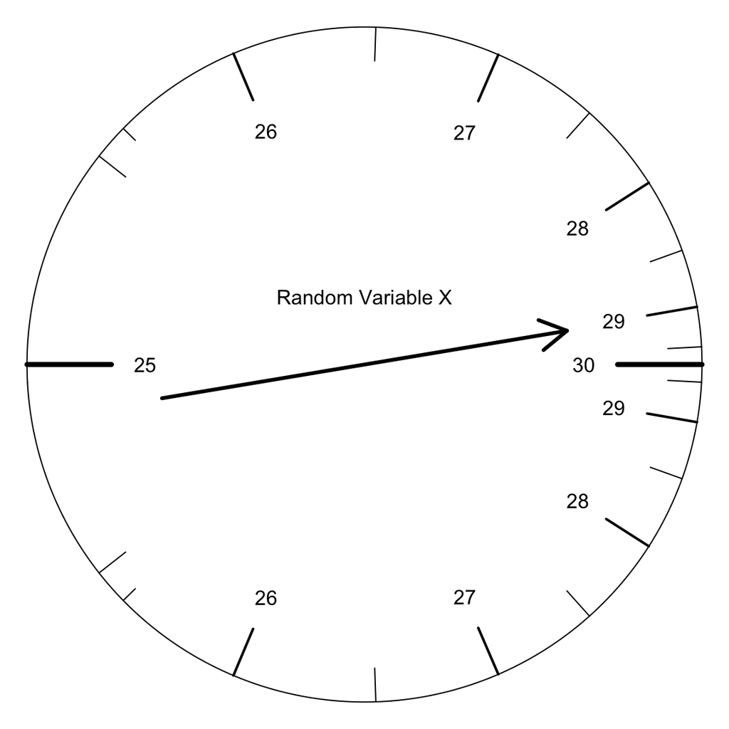

That spinner ($X$) will be fairly spun 492 times, and the **sample mean** of the spins will be recorded. Determine the probability that the random sample mean is more than 26.73.
$$P\left(\bar{X}>26.73\right) ~=~ \,?$$

(Even though single spins are **not** normally distributed, the random means will be normally distributed. See [central limit theorem](https://en.wikipedia.org/wiki/Central_limit_theorem).)

# Solution

[video](https://vimeo.com/531941288)

We use the central limit formulas for a random mean.
$$\mu_{\bar{X}} = \mu_{X} = 26.69$$
$$\sigma_{\bar{X}} = \frac{\sigma_{X}}{\sqrt{n}} =
\frac{1.25}{\sqrt{492}} = 0.0563544$$
So, we think the random mean is normally distributed with a mean of 26.69 and a standard deviation of 0.0563544.
$$\bar{X} \sim
N(26.69,\,0.0563544)$$

Calculate a $z$-score for the boundary.
$$z = \frac{26.73-26.69}{0.0563544}
= 0.7097943$$

You can round that to $z=0.7$ or $z=0.71$. Any of the following probabilities will get credit.
$$P(Z >
0.7097943) = 0.2389158$$
$$P(Z >
0.7) = 0.242$$
$$P(Z > 0.71) =
0.2389$$

To get the probability, you can use a spreadsheet. Either will work:

- `=1-NORMDIST(0.7097943,0,1,TRUE)`
- `=1-NORMDIST(26.73,26.69,0.0563544,TRUE)`

Let’s draw a sketch.

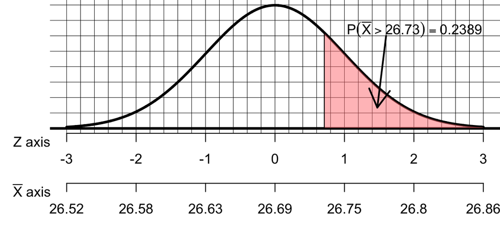

# Meta-information

extype: num exsolution: 0.2389158 exname: prob ave more extol: 0.01